# Tropical Fern Leaf Water Relations

# Background

Below is the compilation of the working data sets we plan to use for the manuscript. Eventually the paper will inclide findings from the following traits (traits in **bold** are analyzed):

- **PV Curves**
- **Stomata: size and density**
- Vein density
- **SLA**
- **Foliar Nitrogen**
- **Isotopes**
- **Morphometrics**
- Phylogeny
- **Chlorophyll**

# Data Analysis

I have set up a linear mixed effect model design for each trait analysis. The general model equation is:

**trait ~ niche2 x site + (1|species)**

Niche2 re-codes our one climbing species as a terrestrial species. In this setup, species is used a a random effect, since individual species effects are not one of our central questions. This model returns 2 R<sup>2</sup> values, one for the whole model and one for the fixed effect only. This allows us to evaluate the amount of variation in a trait attributed solely to species differences.

First, I check for the presence of an interaction. Most of the time there is not one. I also re-run the model with only niche2 and site as main effects, and then evaluate the models against each other (AIC scores). In most cases, I drop the interaction term and use the simplest model. Depending on our question, this setup can change. For example, if we have no interest in site effects, I can embed species within site and treat them both as random effects. Currently, I am using a type 3 ANOVA because we have a unbalanced design (hemi-epiphytes)

# Data visualizations

Below are a series of figures visualizing traits between terrestrial, epiphytic and hemi-epiphytic tropical ferns. I have overlayed the raw data on top of box plots for each treatment. The width or each box plots is proportional to the square-root of the number of observations in each group. If there are significant main effects ($\alpha$ level of 0.05) I have included significance letters from a post-hoc Tukey’s test.

## Frond Morphology

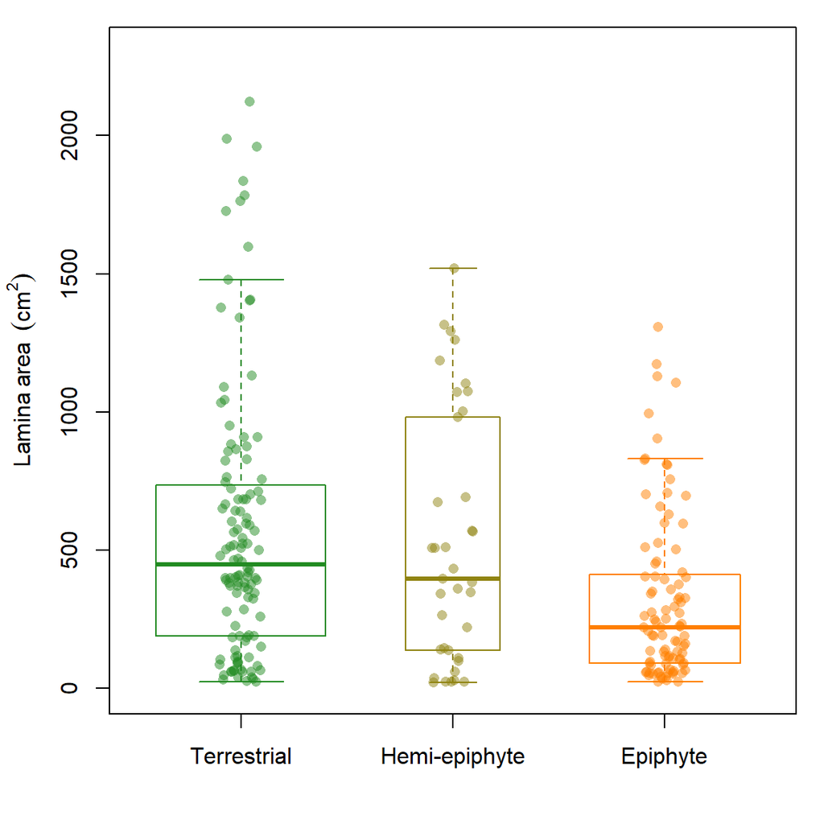

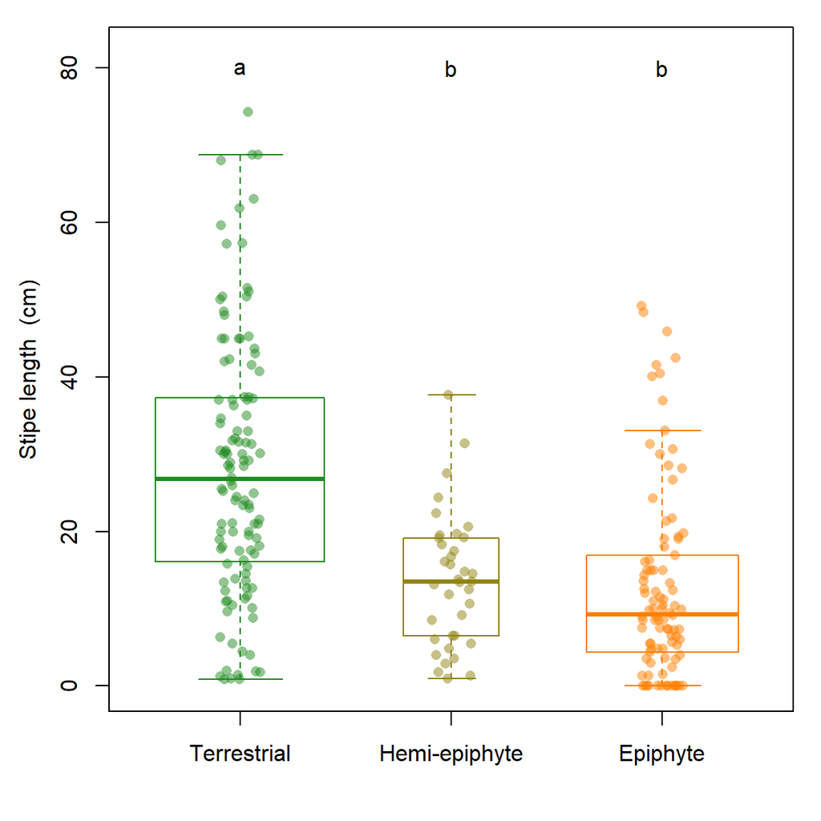

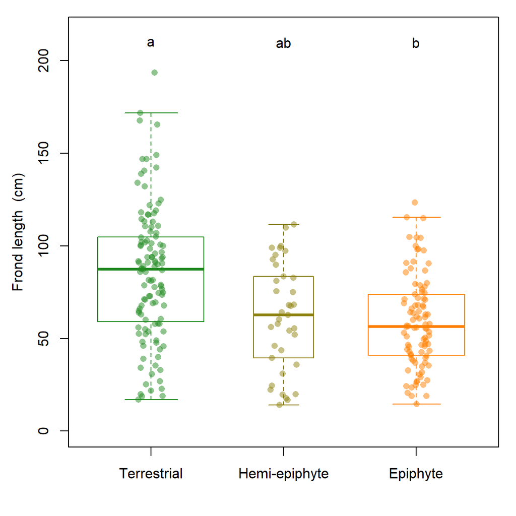

No differences in lamina area, however, this depends on which model I choose (with or without niche x site interaction). There is a massive amount of variation tied up in species-specific differences. Stipes in terrestrial species are 56% longer than epiphytic or hemi-epiphytic species. Total frond length is 30% longer in terrestrial than epiphytic species, with hemi-epiphytic species as intermediates.

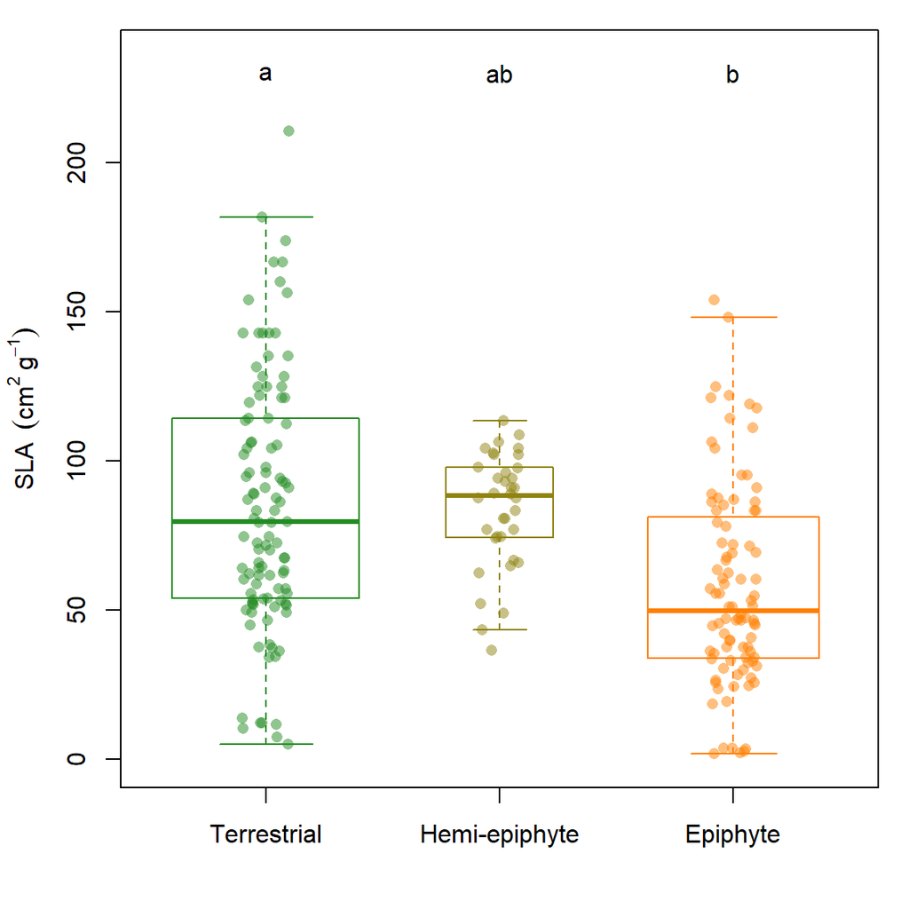

Specific leaf area is 35% higher in terrestrials ferns compared to epiphytic ferns, with hemi-epiphytes as intermediates.

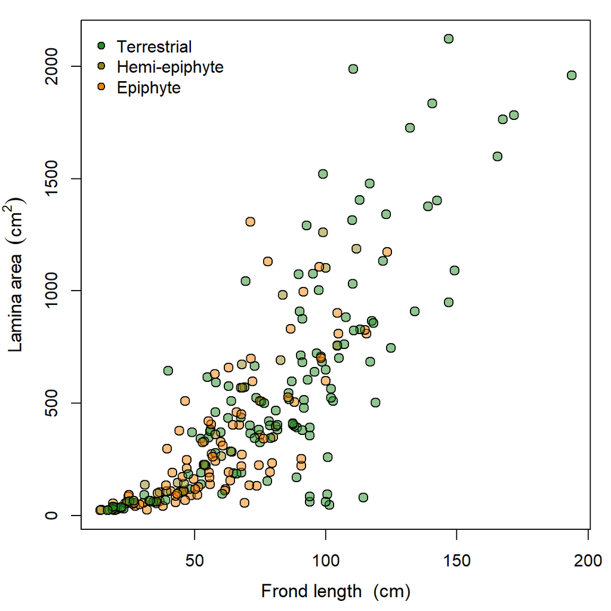

Not surprising, but frond area-length relationships are strong across all fern species.

## Stomatal Traits

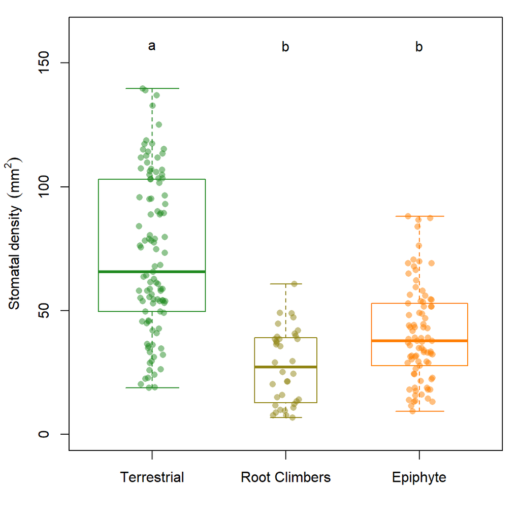

Epiphytic and hemi-epiphytic species have 51% fewer stomata per given area than terrestrial species!

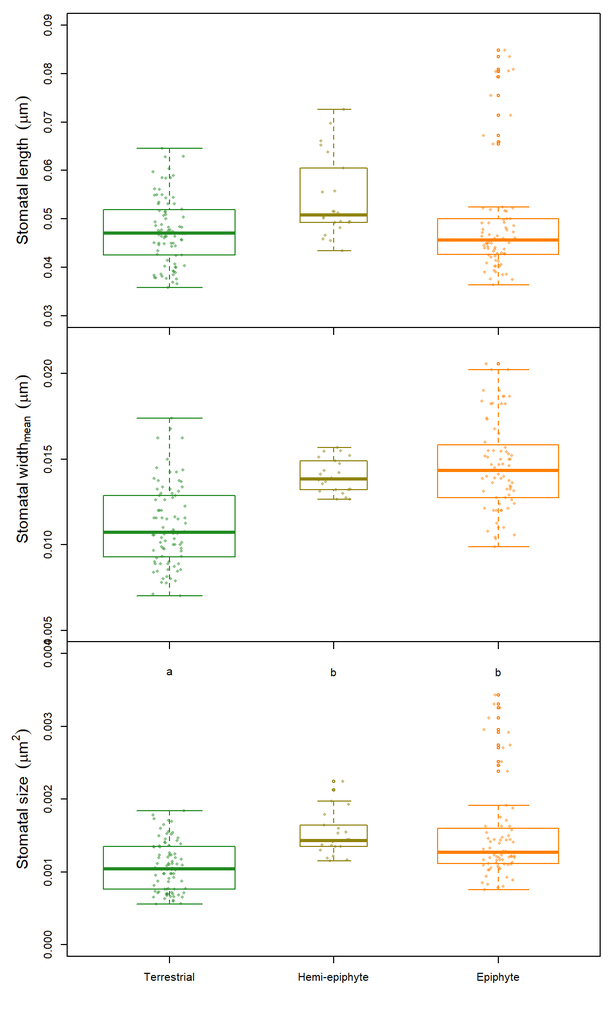

Stomatal size is 40.4% higher epiphytes and hemi-epiphyutes compared to terrestrial species. Stomatal size is calculated as stomatal length x paired guaurd cell width. Average guard cell width drives this response, with stomatal length being similar between habitats.

There are 2 aspenium species that appear to be outliers (epiphytes). There are quite a few indidviudals, within each species that have high values. You can see this from the plots. I am unsure whether or not it is appropriate to drop them. Regardless of whether they are dropped or not, the habitat effect remains. Dropping them adds a messy site interaction. There is also a habitat * site interaction with stomatal width. Terrestrial stomatal only have a smaller width at La Selva.

## Vein Density

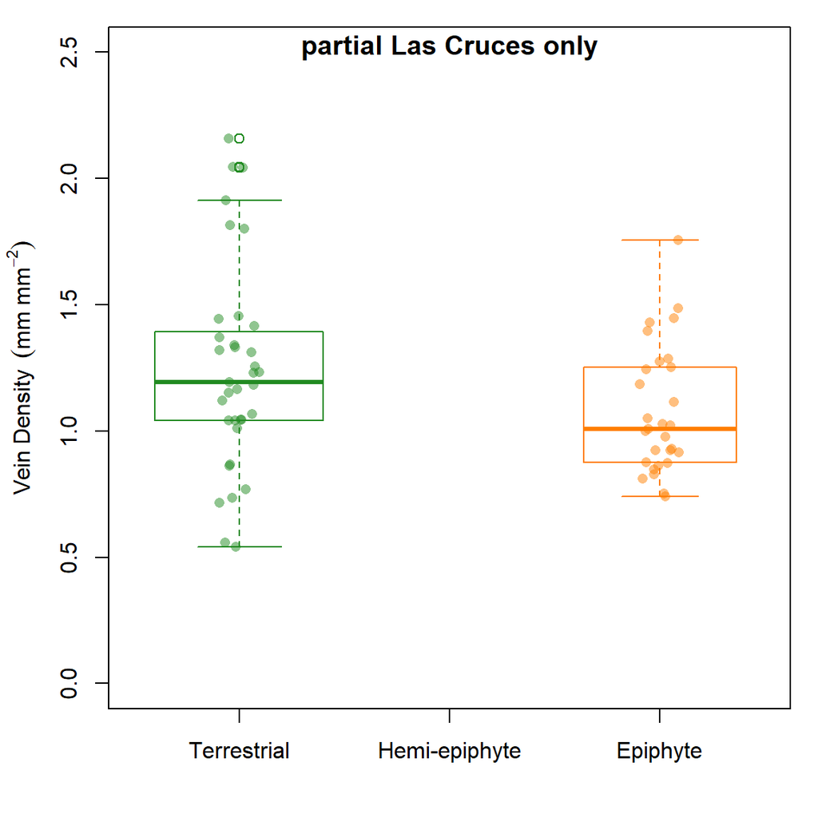

## Foliar Chemistry

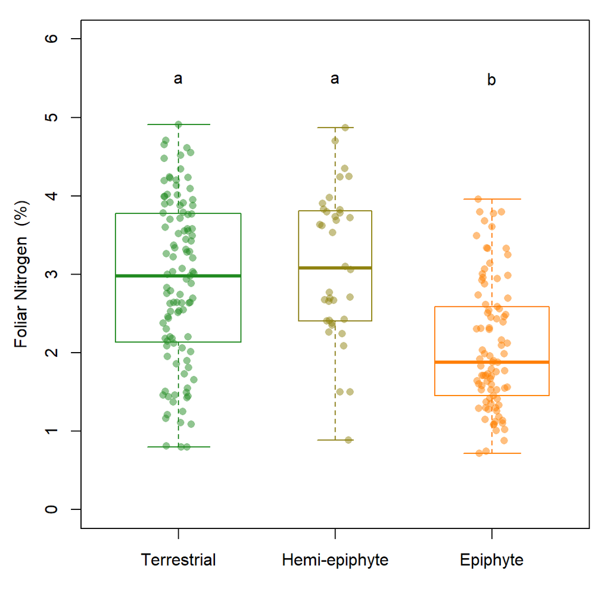

Foliar nitrogen is 29.8% lower in epiphytes compared to other groupgs

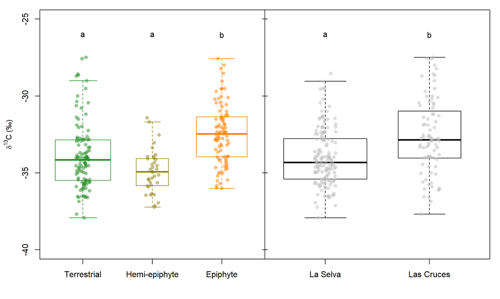

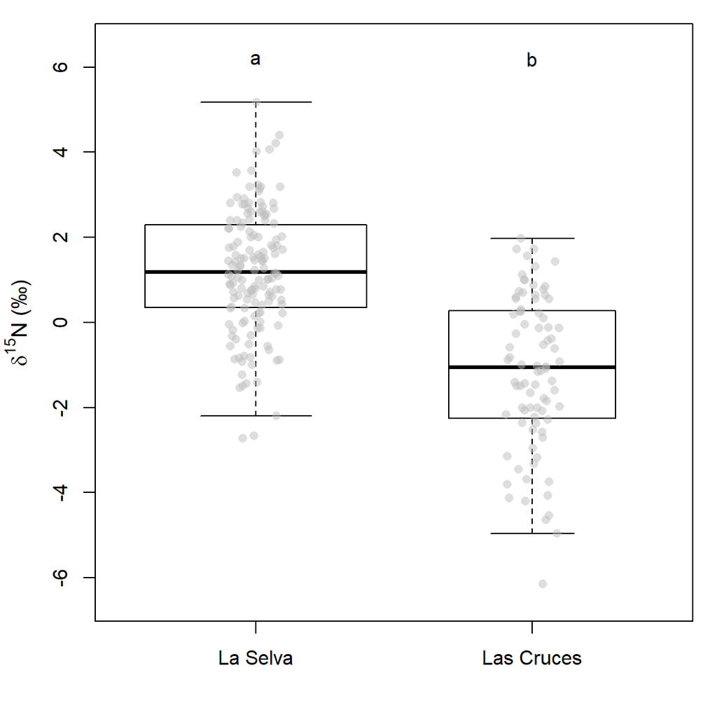

There is only a site effect.

# Chlorophyll Content

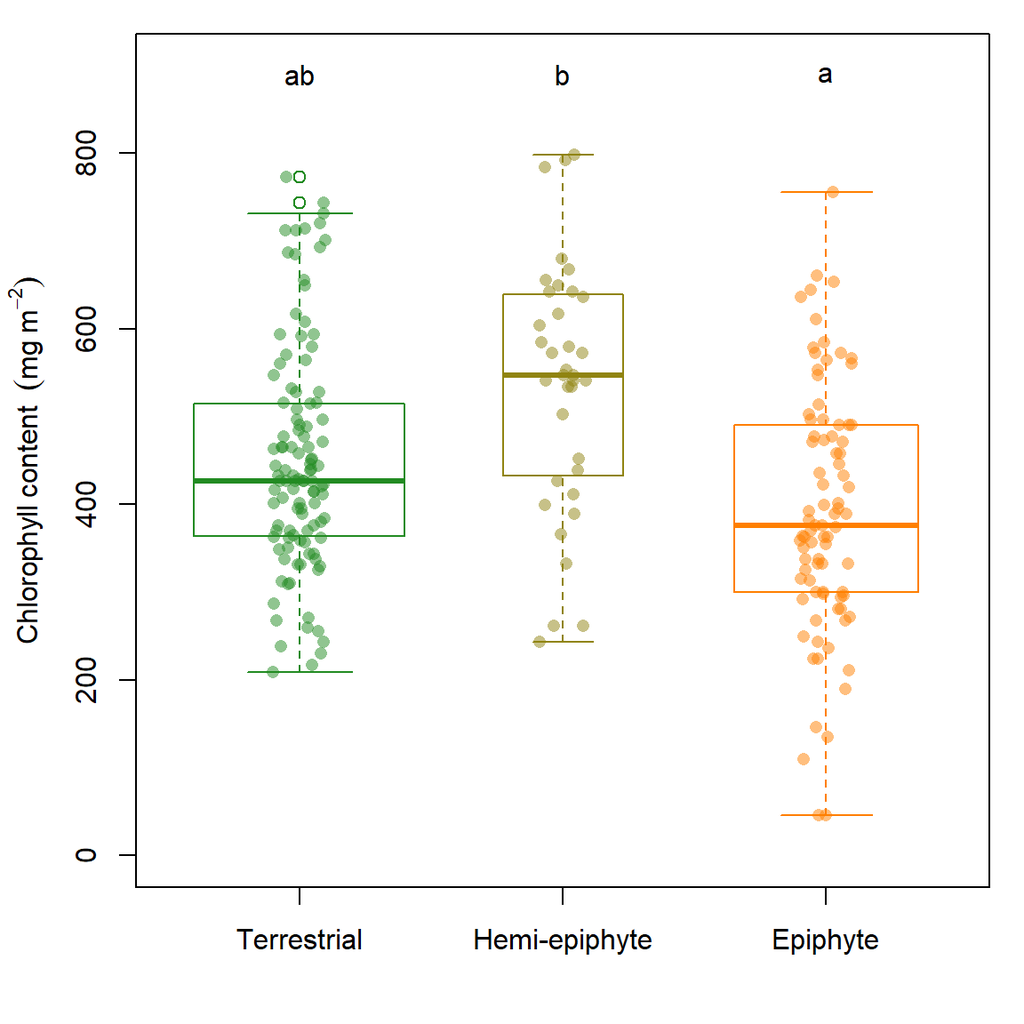

I had to perform a little data mining to get this result. I dropped one epiphytic species with way to variable data (400-800 mg m<sup>-2</sup>) and a few outliers. Not sure how meaningful these differences are.

# Foliar Hydrauliic Traits

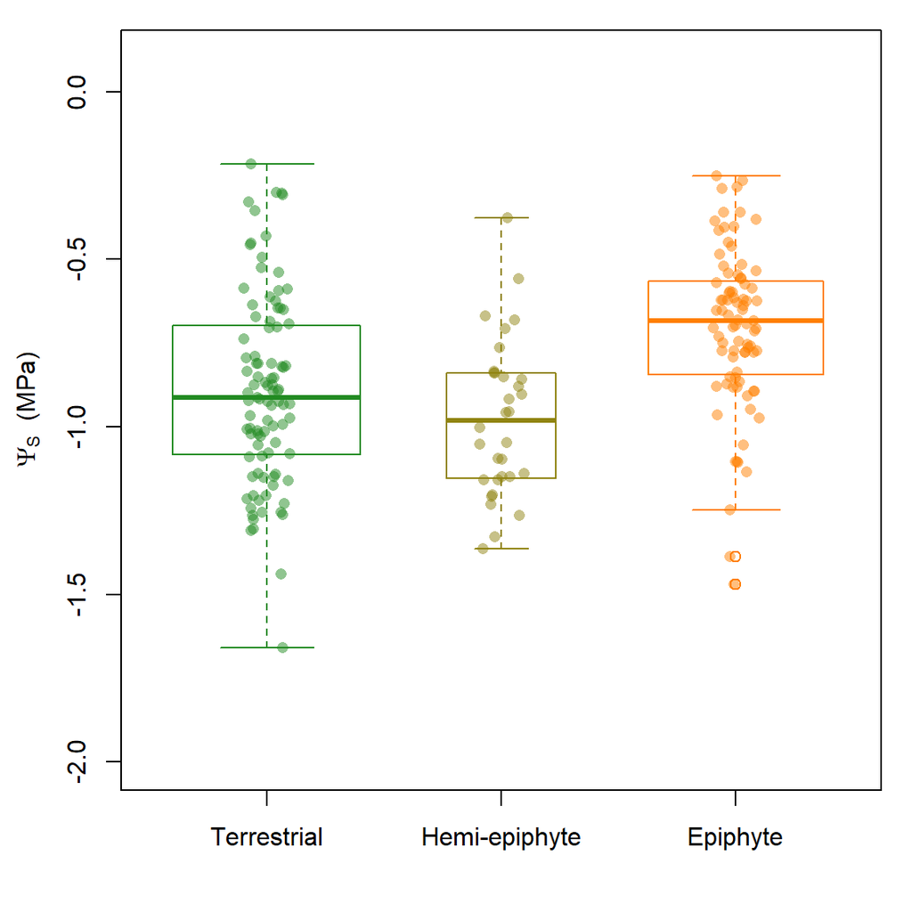

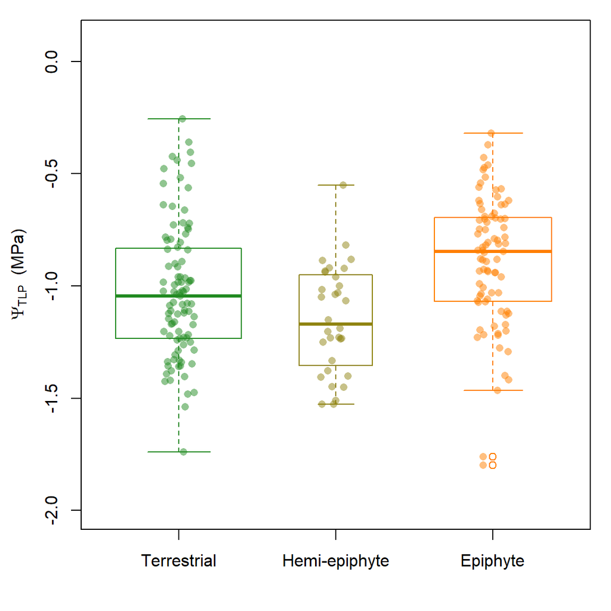

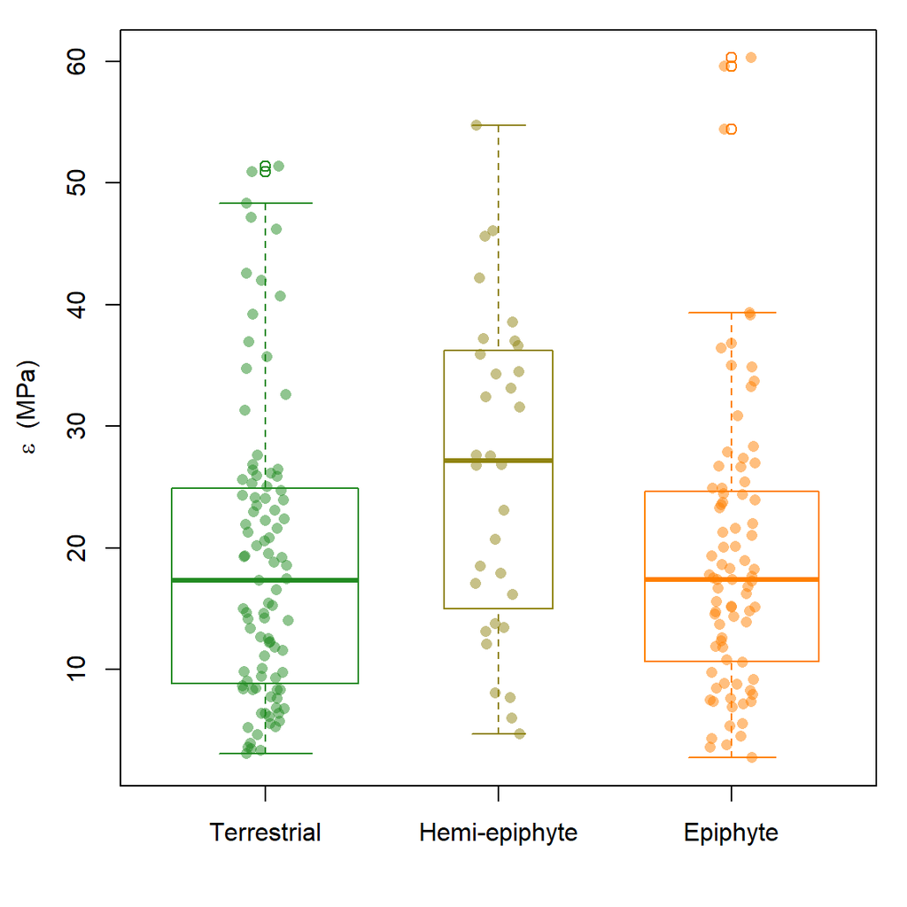

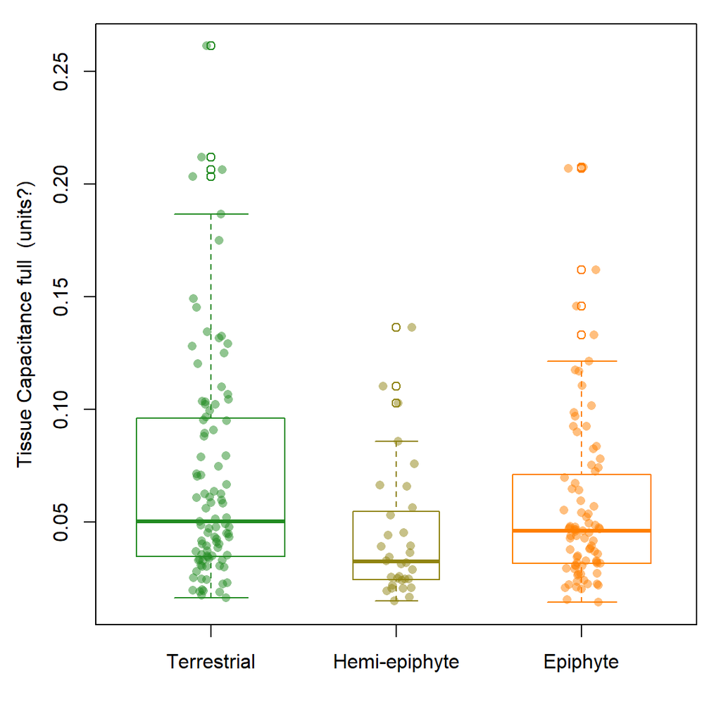

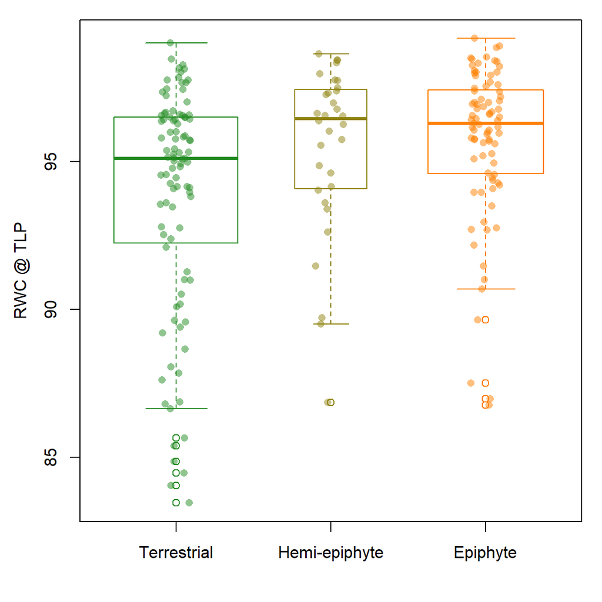

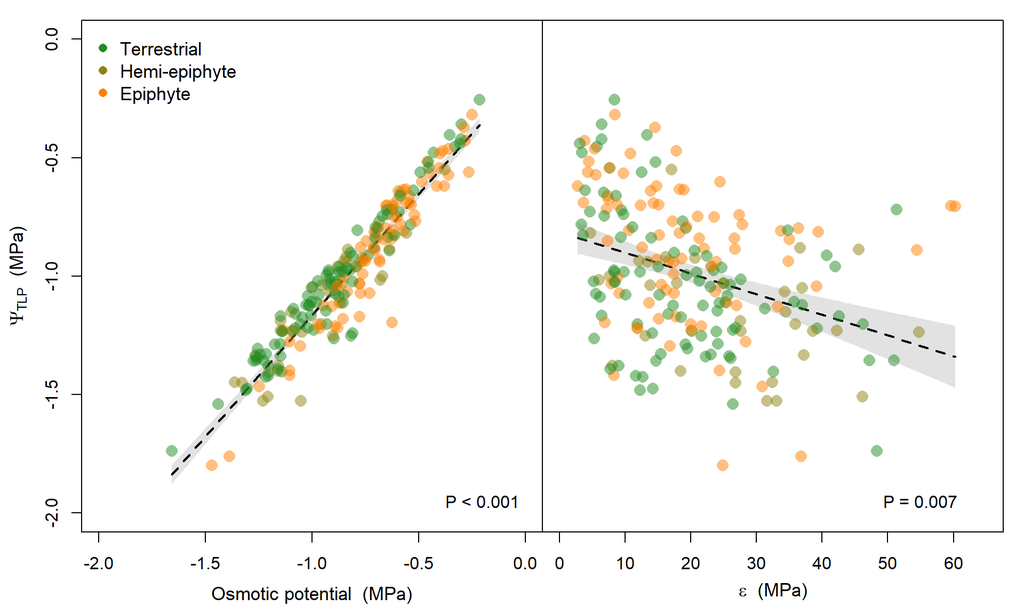

[figure not shown]

Here is a broad snapshot of all the pv curves raw data. It could be cleaner, because all points have been included. This means random bad points or oversaturation points are still in here. It would take forever to go back through each curve. I have also trimmed the x axis. A lot of this could be changed, but wanted to see if you guys were interested.

# Kmax leaf

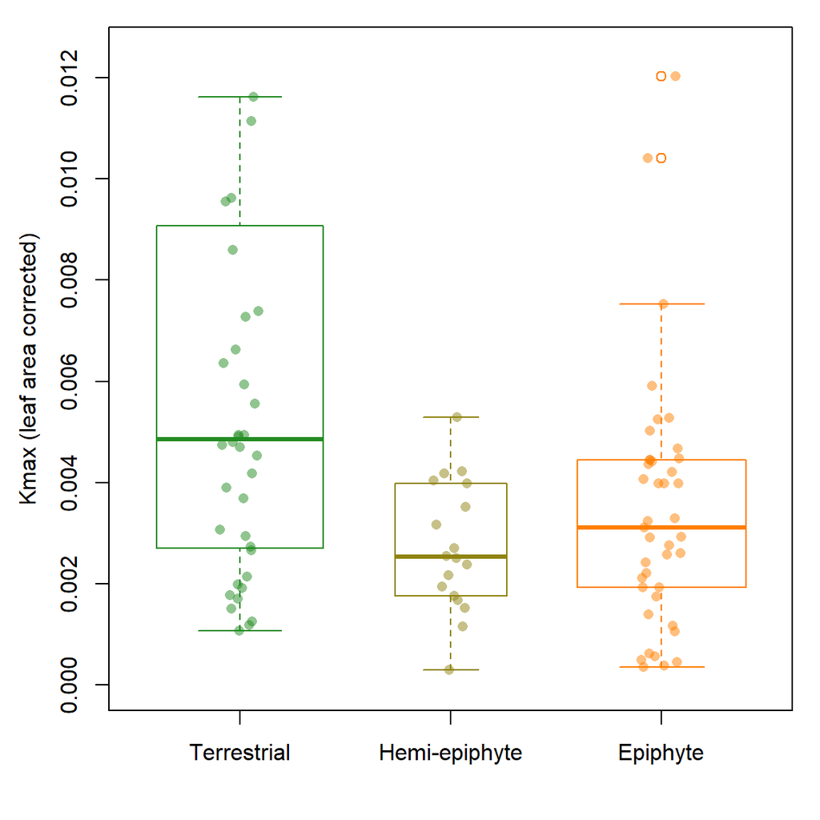

Kleaf is statistically similar among habitats.